# Non-independence: Kinship

## Resources

- Broman: https://kbroman.wordpress.com/2015/11/24/fitting-linear-mixed-models-for-qtl-mapping/
- Falconer DS, Mackay TFC (1996) *Introduction to Quantitative Genetics*. 4th ed. Pearson.
- Lynch M, Walsh B (1998) *Genetics and Analysis of Quantitative Traits*. Sinauer Associates.
- Roff DA (1997) *Evolutionary Quantitative Genetics.* Chapman & Hall.
- Wilson AJ, Réale D, Clements MN, Morrissey MM, Postma E, Walling CA, Kruuk LEB, Nussey DH (2010) An ecologist’s guide to the animal model. *J Anim Ecol* 79:13-26.
- Yang J, Zaitlen NA, Goddard ME, Visscher PM, Price AL (2014) Advantages and pitfalls in the application of mixed-model association methods. *Nat Genet* 46:100-106.

## Kinship (non-independence) as a tool

When modeled correctly, non-independence between samples can be very useful:

- Forms the basis for how we estimate heritabilities, genetic correlations, etc.
- Very similar in concept to repeatability
- Estimate the variance within families/lines (groups) versus between families/lines
- Modern methods can consider complex pedigrees or relatedness estimated directly from genomic data

## Heritability and genetic correlation

[figure not shown]

## Load pedigree

```r
library(MCMCglmm)
library(kinship2)

data(BTped)
str(BTped)
```

```
## 'data.frame':    1040 obs. of  3 variables:
##  $ animal: Factor w/ 1040 levels "Fem2","Fem20",..: 669 671 680 630 640 1007 3 158 629 635 ...
##  $ dam   : Factor w/ 106 levels "Fem2","Fem20",..: NA NA NA NA NA NA NA NA NA NA ...
##  $ sire  : Factor w/ 106 levels "Male10","Male100",..: NA NA NA NA NA NA NA NA NA NA ...
```

## Look at part of pedigree

```
##       animal     dam    sire
## 66   R187920    <NA>    <NA>
## 172  R187921    <NA>    <NA>
## 325  R187726 R187920 R187921
## 411  R187724 R187920 R187921
## 503  R187723 R187920 R187921
## 838  R187613 R187920 R187921
## 932  R187612 R187920 R187921
## 1030 R187609 R187920 R187921
```

## Plot part of pedigree

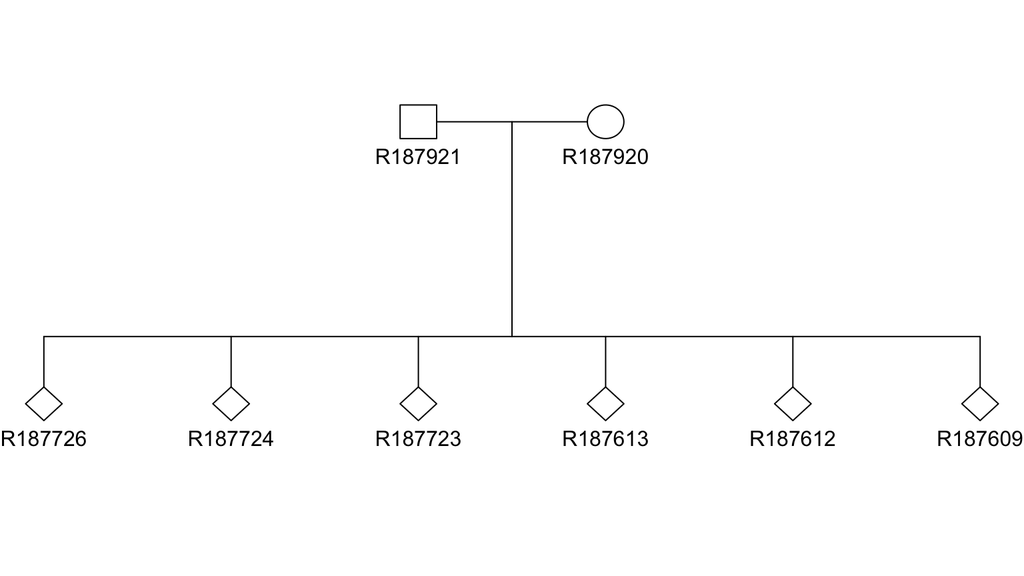

## Genetic distance

```
##         R187920 R187921 R187726 R187724 R187723 R187613
## R187920     1.0     0.0     0.5     0.5     0.5     0.5
## R187921     0.0     1.0     0.5     0.5     0.5     0.5
## R187726     0.5     0.5     1.0     0.5     0.5     0.5
## R187724     0.5     0.5     0.5     1.0     0.5     0.5
## R187723     0.5     0.5     0.5     0.5     1.0     0.5
## R187613     0.5     0.5     0.5     0.5     0.5     1.0
```

## Data

```r
data(BTdata)
head(BTdata)
```

```
##        tarsus       back  animal     dam fosternest  hatchdate  sex
## 1 -1.89229718  1.1464212 R187142 R187557      F2102 -0.6874021  Fem
## 2  1.13610981 -0.7596521 R187154 R187559      F1902 -0.6874021 Male
## 3  0.98468946  0.1449373 R187341 R187568       A602 -0.4279814 Male
## 4  0.37900806  0.2555847 R046169 R187518      A1302 -1.4656641 Male
## 5 -0.07525299 -0.3006992 R046161 R187528      A2602 -1.4656641  Fem
## 6 -1.13519543  1.5577219 R187409 R187945      C2302  0.3502805  Fem
```

## Heritability of tarsus length

```r
prior <- list(R = list(V = 0.002, n = 2),
              G = list(G1 = list(V = 0.002, n = 2)))

fm1 <- MCMCglmm(
  fixed = tarsus ~ 1,
  random = ~ animal,
  prior = prior,
  family = c("gaussian"),
  nitt = 60000, burnin = 10000, thin = 25,
  data = BTdata, pedigree = BTped,
  verbose = FALSE)
save(fm1, file = "../data/BT_herit.Rda")
```

## Fixed effects

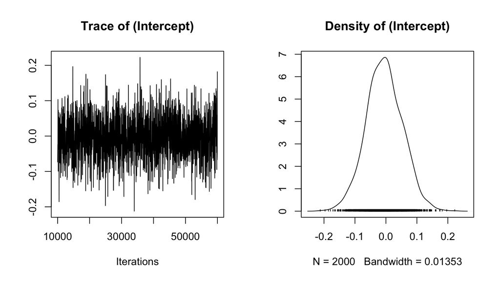

```r
plot(fm1$Sol)
```

## Random effects

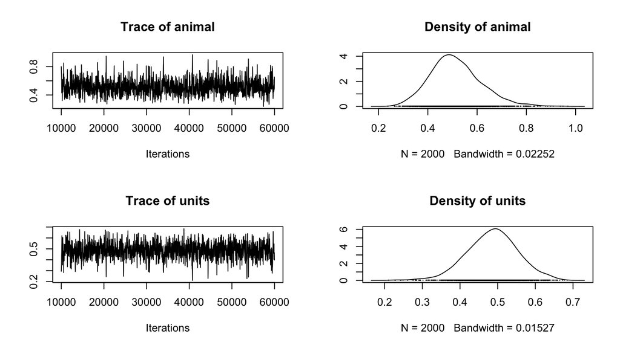

```r
plot(fm1$VCV)
```

## Heritability

\[h^2 = \frac{V_a}{V_a + V_r}\]

```r
h2 <- fm1$VCV[, "animal"] /
  (fm1$VCV[, "animal"] + fm1$VCV[, "units"])
```

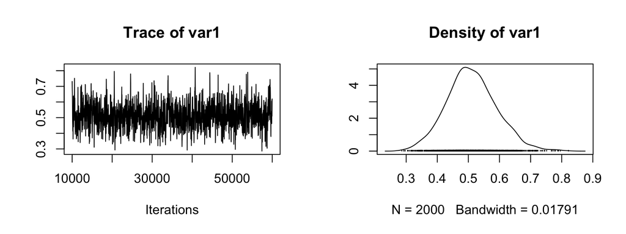

## Heritability

```r
median(h2)
```

```
## [1] 0.5071815
```

```r
HPDinterval(h2)
```

```
##          lower     upper
## var1 0.3451464 0.6579368
## attr(,"Probability")
## [1] 0.95
```

## Genetic correlation

```r
prior <- list(R = list(V = diag(2) * 1.001, n = 2),
              G = list(G1 = list(V = diag(2)  * 1.001, n = 2)))

fm2 <- MCMCglmm(
  fixed = cbind(back, tarsus) ~ trait,
  random = ~ us(trait):animal,
  rcov = ~ us(trait):units,
  prior = prior,
  family = c("gaussian", "gaussian"),
  nitt = 60000, burnin = 10000, thin = 25,
  data = BTdata, pedigree = BTped,
  verbose = FALSE)
save(fm2, file = "../data/BT_genetic_correlation.Rda")
```

## Genetic correlation

```r
Genet_Corr <- fm2$VCV[ , "traittarsus:traitback.animal"] /
  sqrt(fm2$VCV[ , "traittarsus:traittarsus.animal"] *
         fm2$VCV[ , "traitback:traitback.animal"])
```

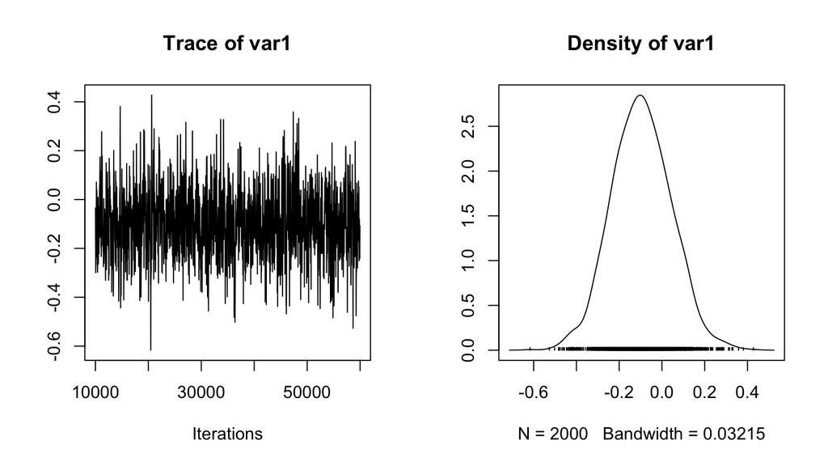

## Genetic correlation

```r
median(Genet_Corr)
```

```
## [1] -0.09755932
```

```r
HPDinterval(Genet_Corr)
```

```
##           lower     upper
## var1 -0.3499248 0.1825534
## attr(,"Probability")
## [1] 0.95
```

## Kinship and GWAS

When individuals are related in different ways, correcting for kinship is critical to avoid spurious associations. This is necessary even when not including close relatives (e.g., siblings, cousins, etc.)

Typical data:

- Hundreds of thousands to millions of SNPs
- Phenotypes
- Hundreds to thousands of individuals
- That’s **a lot** of tests! (speed matters)

## Kinship and GWAS

The typical model is a Linear Mixed Model (LMM) with fixed and random effects.

\[Y = W\beta + G\gamma + g + e\]

*Y* is the phenotype

Fixed effects:

- *W* is a covariate (or more than one) with \(\beta\) as the coefficient(s)
- *G* is the genotype with \(\gamma\) as the coefficient

## Kinship and GWAS

The typical model is a Linear Mixed Model (LMM) with fixed and random effects.

\[Y = W\beta + G\gamma + g + e\]

Random effects:

- *g* is a vector of polygenic effects scaled according to relatedness between individuals
- *e* is the error term

## Kinship Matrix

Kinship matrix can be

- Estimated from a pedigree
- Estimated from the genomic data

## Mice on Meth

[figure not shown]

## Mice on Meth

[figure not shown]

## Quiz 11-3

No more lectures

## References

Falconer, D. S., and T. F. C. Mackay. 1996. *Introduction to Quantitative Genetics*. 4th ed. Pearson.

Lynch, M., and B. Walsh. 1998. *Genetics and Analysis of Quantitative Traits*. Sinauer Associates.

Roff, D. A. 1997. *Evolutionary Quantitative Genetics*. Chapman & Hall.

Wilson, A. J., D. Réale, M. N. Clements, M. M. Morrissey, E. Postma, C. A. Walling, L. E. B. Kruuk, and D. H. Nussey. 2010. An Ecologist’s Guide to the Animal Model. *The Journal of animal ecology* 79:13–26.

Yang, J., N. A. Zaitlen, M. E. Goddard, P. M. Visscher, and A. L. Price. 2014. Advantages and Pitfalls in the Application of Mixed-Model Association Methods. *Nature Genetics* 46:100–106.